# RaMWAS data structures

Andrey Shabalin

2016-04-08

# Loading and Saving RaMWAS objects

All RaMWAS objects except for filematrices are saved to files and loaded back with `saveRDS` and `readRDS` functions.

```r
filename = system.file("extdata", "cpgset.rds", package = "ramwas");
cpgset = readRDS(filename);
show(cpgset)
```

```
## $chr1
## [1]  12  57 123
##
## $chr2
## [1]  45  95  99 111
##
## $chr3
## [1]  22  40 199 211
```

# Set of CpG locations

RaMWAS calculates coverage at a precalculated set of CpG. The set depends on the reference genome and usually includes CpGs created by common SNPs. The set of CpGs is stored as a `list` with one sorted vector of CpG locations per chromosome.

Here is an examplep of CpG set data structure:

```r
cpgset = list( chr1 = c(12L, 57L, 123L),
               chr2 = c(45L, 95L, 99L, 111L),
               chr3 = c(22L, 40L, 199L, 211L) );
```

# Rbam data structure

RaMWAS scans large BAM files into an economical R representation with `bam.scanBamFile` function.

```r
suppressPackageStartupMessages(library(ramwas))
filename = system.file("extdata", "small.bam", package = "ramwas");
rbam = bam.scanBamFile(filename, scoretag = "AS", minscore = 80 )
```

```
## Recorded 26 of 58 reads
```

The resulting R object is a `list` with 3 components. First two, `$startsfwd` and `$startsrev`, contain read start positions for forward and reverse strands respectively.

```r
head(names(rbam$startsfwd))
```

```
## [1] "chr1" "chr2" "chr3" "chr4" "chr5" "chr6"
```

```r
rbam$startsfwd$chr2
```

```
## [1]  49536829 135972038
```

```r
rbam$startsrev$chr1
```

```
## [1] 46505281
```

The `$qc` component holds the quality control measures.

## Rbam quality control measures

All QC measures are designed to be additive, in the sence that any QC measure calculated for a concatination of two BAM files is equal to the sum of the respective measure calculated for those BAMs separately.

The `small.bam` above has too few reads for meaning QC distributions. Thus we load a small Rbam object with all the QC measures.

```r
filename = system.file("extdata", "qc_sample.rds", package = "ramwas");
rbam = readRDS(filename);
```

The currently supported QC measures include th following

### Total number of reads in the BAM file

```r
rbam$qc$reads.total
```

```
## [1] 3790126
```

### Number of reads in the BAM file aligned to the reference genome

```r
rbam$qc$reads.aligned
```

```
## [1] 3721452
```

### Number of reads that passed minimum score filter and are recorded in Rbam object

```r
rbam$qc$reads.recorded
```

```
## [1] 3609306
```

```r
# sum(sapply(rbam$startsfwd,length)) + sum(sapply(rbam$startsrev,length))
```

### Number of recorded reads aligned to the forward and reverse strands respectively

```r
rbam$qc$frwrev
```

```
## [1] 1804449 1804857
```

```r
# c(sum(sapply(rbam$startsfwd,length)), sum(sapply(rbam$startsrev,length)))
```

### Distribution of the length of the aligned part of the reads recorded in Rbam

This QC measure is recorded in `$hist.length.matched`. The first element contains the number of reads with 1 aligned basepair, the second with 2, and so on. The length of the aligned part of the reads is calculated from the CIGAR strings in the BAM file.

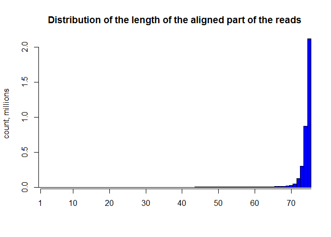

```r
barplot(rbam$qc$hist.length.matched/1e6, width = 1, space = 0, col = "blue", main = "Distribution of the length of the aligned part of the reads", xaxs="i", yaxs="i", ylab = "count, millions");
at = seq(0,length(rbam$qc$hist.length.matched)+10,10);
at[1] = 1;
axis(1,at = at-0.5, labels = at)
```

### Distribution of edit distance between the aligned part of the read and the reference genome

This QC measure is recorded in `$hist.edit.dist1`. The first element contains the number of reads with 0 edit distance (perfect match), the second with edit distance 1, and so on.

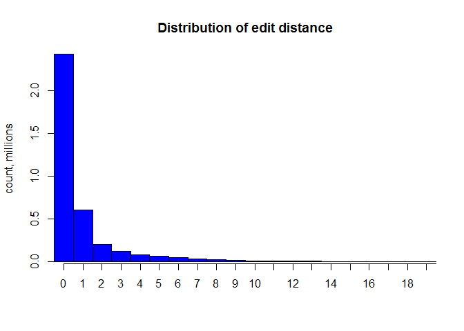

```r
barplot(rbam$qc$hist.edit.dist1/1e6, width = 1, space = 0, col = "blue", main = "Distribution of edit distance", xaxs="i", yaxs="i", ylab = "count, millions");
at = seq(0,length(rbam$qc$hist.edit.dist1)+10,1);
axis(1,at = at+0.5, labels = at)
```

The edit distance is obtained from the NM tag in the BAM file.

### Distribution of the read score (as defined by `scoretag` in the call of `bam.scanBamFile()`)

This QC measure is recorded in `$hist.score1`. The first element contains the number of reads with score of 0, the second with score of 1, and so on. Negative scores are ignored.

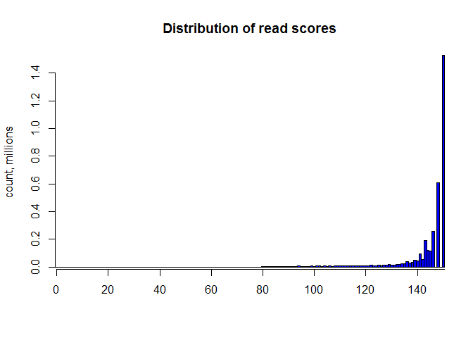

```r
barplot(rbam$qc$hist.score1/1e6, width = 1, space = 0, col = "blue", main = "Distribution of read scores", xaxs="i", yaxs="i", ylab = "count, millions");
at = seq(0,length(rbam$qc$hist.score1)+10,20);
axis(1,at = at+0.5, labels = at)
```